# Laboratório 3 - Parte 2: Prevendo Evasão

Arthur Lustosa

20 de fevereiro de 2017

Este problema dá continuação a uma análise iniciada [aqui](https://github.com/arthurlustosa/ad2/blob/master/lab3/lab3-parte1.Rmd). Nosso objetivo agora é prever a evasão dos alunos do curso de Ciência da Computação da UFCG por meio de algoritmos de predição. Utilizaremos a seguinte estratégia para verificar a evasão, se o aluno cursou o primeiro período inteiro vamos tentar prever se ele se matriculará ou não no segundo período. Caso ele não se matriculou é porque abandonou o curso ou solicitou desligamento.

Para iniciar nossa análise vamos importar as bibliotecas necessárias

```r
library(dplyr)
library(ggplot2)
library(plotly)
library(reshape2)
library(caret)
library(glmnet)
```

Lendo os dados

```r
dados <- read.csv("dados/treino_classificacao_v2.csv")
colnames(dados) <- c("Matricula", "Matricula_Turma", "Disciplina", "Ano", "Periodo","Media_Final", "evadiu")

#adicionando novo atributo
dados = group_by(dados, Matricula) %>% mutate(count = n(), n_reprovacoes = sum(Media_Final < 5))

# Criando o atributo
reprovacoes <- function(medias) {
  temp <- medias[medias < 5]
  return(length(temp))
}

dados <- dados %>%
  group_by(Matricula) %>%
  mutate(num_reprovacoes = reprovacoes(medias = Media_Final))

dados <- dados %>%
  filter(!is.na(Media_Final))

dados <- dados %>%
  group_by(Matricula, Disciplina) %>%
  filter(Media_Final == max(Media_Final))%>%
  ungroup() %>%
  select(Matricula, Disciplina, Media_Final, evadiu, Ano, num_reprovacoes) %>%
  mutate(Disciplina = as.factor(gsub(" ", ".", Disciplina))) %>%
  dcast(Matricula + evadiu + Ano + num_reprovacoes ~Disciplina, value.var = "Media_Final")

 colnames(dados) <- c("matricula", "evadiu", "ano", "num_reprovacoes","Vetorial", "C1", "IC", "LP1", "LPT", "P1")
```

O atributo criado foi a contagem do número de reprovações que o aluno teve. Para isso, analisando as notas finais nas disciplinas, caso fosse < 5 o aluno foi reprovado, fizemos a contagem dessas ocorrências e armazenamos numa coluna.

A imputação dos dados, ao analisar os dados observamos um número significativos de NAs nas notas das disciplinas, por isso optamos em realizar a inputação dos dados manualmente. Separamos as disciplinas por departamentos e por exemplo, se a média de vetorial estiver faltando, colocaremos a média de cálculo 1 o mesmo caso contrário. O mesmo fizemos para P1 e LP1, nos casos de IC e LPT usamos a média das demais disciplinas.

```r
#imputando os dados
dados <- dados %>%
  mutate(Vetorial = ifelse(is.na(Vetorial),
                            ifelse(is.na(C1),
                                   0.0,
                                   C1),
                            Vetorial),
        C1 = ifelse(is.na(C1),
                            ifelse(is.na(Vetorial),
                                   0.0,
                                   Vetorial),
                            C1),
        LP1 = ifelse(is.na(LP1),
                            ifelse(is.na(P1),
                                   0.0,
                                   P1),
                            LP1),
        P1 = ifelse(is.na(P1),
                            ifelse(is.na(LP1),
                                   0.0,
                                   LP1),
                            P1),
        IC = ifelse(is.na(IC),
                    round(mean(c(Vetorial, C1, LP1, P1)), 2),
                    IC),
        LPT = ifelse(is.na(LPT),
                    round(mean(c(Vetorial, C1, LP1, P1)), 2),
                    LPT)
        )
```

### 1.Separando dados em treino e teste

Optamos por dividir os dados em treino e teste, observamos que a partir de 2011 temos um aumento considerável no número de matrículas, isso devido aos incentivos do governo em facilitar a entrada dos alunos na universidade, por isso os dados de treino são equivalentes aos anos de 2011 e 2014 e os de teste ao ano de 2015.

```r
train.data <- dados %>%
  filter(ano >= 2011 & ano <= 2014)

test.data <- dados %>%
  filter(ano == 2015)

train.data$evadiu = as.factor(train.data$evadiu)
test.data$evadiu = as.factor(test.data$evadiu)
```

### 2.Treino - Modelos de regressão logística

```r
model.gml = train(evadiu ~. -matricula,
                   data=train.data,
                   method="glm",
                   family="binomial",
                   na.action=na.omit)
```

### 3.Treino - Modelos de árvore de decisão

```r
library("rpart")
decision.tree.fit <- rpart(evadiu ~ . -matricula, data=train.data)
```

### 4.Interpretação de coeficientes da regressão

```r
summary(model.gml)
```

```
##
## Call:
## NULL
##
## Deviance Residuals:
##     Min       1Q   Median       3Q      Max
## -1.9761  -0.2839  -0.1993  -0.1434   3.2237
##
## Coefficients:
##                   Estimate Std. Error z value Pr(>|z|)
## (Intercept)      36.080671 361.567423   0.100   0.9205
## ano              -0.017989   0.179766  -0.100   0.9203
## num_reprovacoes   0.514966   0.229903   2.240   0.0251 *
## Vetorial          0.050520   0.131305   0.385   0.7004
## C1                0.056386   0.144857   0.389   0.6971
## IC               -0.003907   0.113683  -0.034   0.9726
## LP1               0.370833   0.478278   0.775   0.4381
## LPT              -0.372561   0.162612  -2.291   0.0220 *
## P1               -0.626555   0.475639  -1.317   0.1877
## ---
## Signif. codes:  0 '***' 0.001 '**' 0.01 '*' 0.05 '.' 0.1 ' ' 1
##
## (Dispersion parameter for binomial family taken to be 1)
##
##     Null deviance: 298.49  on 478  degrees of freedom
## Residual deviance: 186.84  on 470  degrees of freedom
## AIC: 204.84
##
## Number of Fisher Scoring iterations: 6
```

Ao analisar os coeficientes do nosso modelo, as variáveis mais significativas são LPT e o nosso atributo criado num_reprovações. Porém essas variáveis apresentam os menores p-valores, o que não faz muito sentido, acreditamos que essa importância que o modelo mostrou seja resultado da imputação dos dados.

### 5.Acurácia, precision e recall no treino e teste

- **TP**: true-positive;
- **TN**: true-negative;
- **FP**: false-positive;
- **FN**: false-negative.
- **Acurácia**: proporção de observações corretamente classificadas. (TP+TN)/(TP+TN+FP+FN);
- **Precisão**: quantas das observaçoes preditas como positivas são realmente positivas. TP/(TP+FP);
- **Recall**: quantas observaçoes positivas foram corretamente classificadas. TP/(TP+FN).

```r
test.data$glm.prediction <- predict(model.gml, test.data)
temp <- test.data %>% select(evadiu, glm.prediction)

TP <- temp %>% filter(evadiu == TRUE, glm.prediction == TRUE) %>% nrow()
TN <- temp %>% filter(evadiu == FALSE, glm.prediction == FALSE) %>% nrow()
FP <- temp %>% filter(evadiu == FALSE, glm.prediction == TRUE) %>% nrow()
FN <- temp %>% filter(evadiu == TRUE, glm.prediction == FALSE) %>% nrow()
```

Analisando as métricas temos uma acurácia de 0.93, precisão de 0.67 e recall de 0.588. Nosso modelo apresentou uma boa acurácia, cerca de 93% das previsões estão corretas, mas as outras métricas não foram tão boas assim. A precisão nos diz que 33% das vezes o modelo previu que o aluno ia evadir, mas isso não aconteceu e o recall nos diz que o modelo só conseguiu prever 58% dos alunos que evadiram. Como já vimos, as classes estão desbalanceadas e por isso a acurácia não é confiante.

```
## [1] "Accuracy 0.936507936507937"
```

```
## [1] "Precision 0.666666666666667"
```

```
## [1] "Recall 0.588235294117647"
```

Vamos analisar essa métricas para o modelo de arvore de decisão.

```r
dt.prediction <- as.data.frame(predict(decision.tree.fit, test.data))
temp <- apply(dt.prediction['TRUE'], 2, FUN = function(x){return(x > 0.5)})
test.data$dt.prediction <- as.factor(temp)

temp <- test.data %>% select(evadiu, dt.prediction)

TP <- temp %>% filter(evadiu == TRUE, dt.prediction == TRUE) %>% nrow()
TN <- temp %>% filter(evadiu == FALSE, dt.prediction == FALSE) %>% nrow()
FP <- temp %>% filter(evadiu == FALSE, dt.prediction == TRUE) %>% nrow()
FN <- temp %>% filter(evadiu == TRUE, dt.prediction == FALSE) %>% nrow()
```

```
## [1] "Accuracy 0.952380952380952"
```

```
## [1] "Precision 0.7"
```

```
## [1] "Recall 0.823529411764706"
```

### 6.Controle overfitting usando validação-cruzada

**Regressão Logistica**

**Ridge**

O modelo de regressão para Ridge ajustado utiliza a função glmnet com alpha igual a 0. Temos que quando o lambda é 4, todos os coeficiente são zero. Então, à medida que variamos lambda, os coeficiente crescem distanciando de zero.

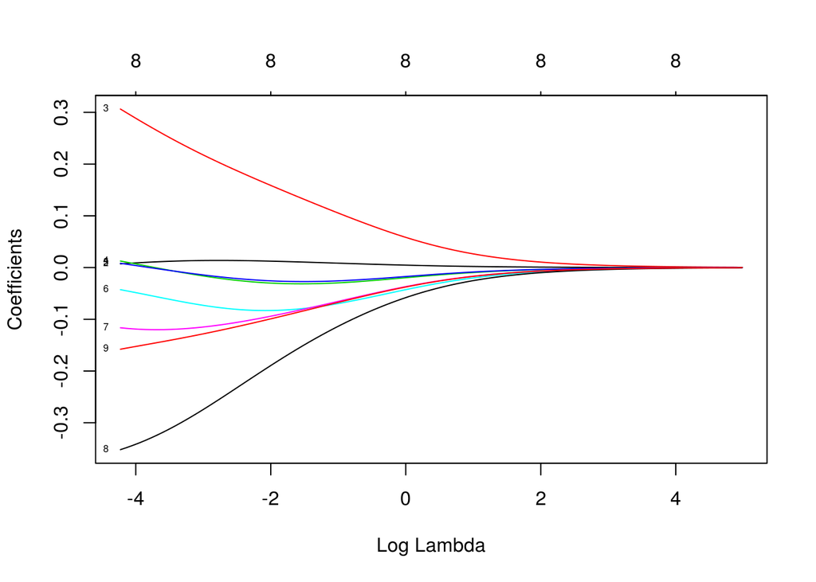

```r
set.seed(123)

model.ridge = glmnet(x = model.matrix( ~ . -matricula -evadiu, train.data),
                y = train.data$evadiu,
                alpha = 0,
                family = 'binomial')

plot(model.ridge, xvar = "lambda", label = T)
```

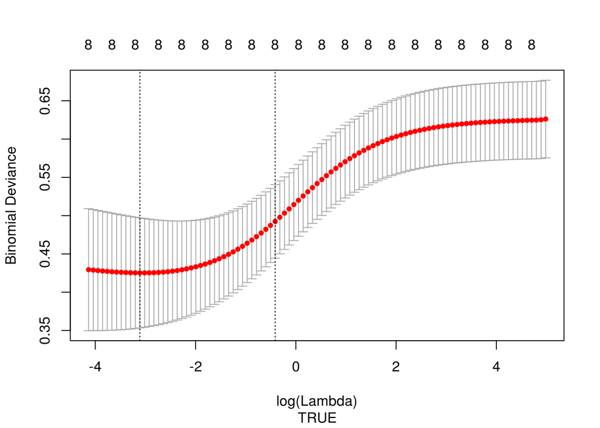

```r
cv.ridge = cv.glmnet(model.matrix( ~ . -matricula -evadiu, train.data), y=train.data$evadiu, alpha=0, family="binomial")

plot(cv.ridge, sub = T)
```

**Lasso**

O modelo de regressão para lasso é ajustado chamando a função glmnet com alpha igual a 1.

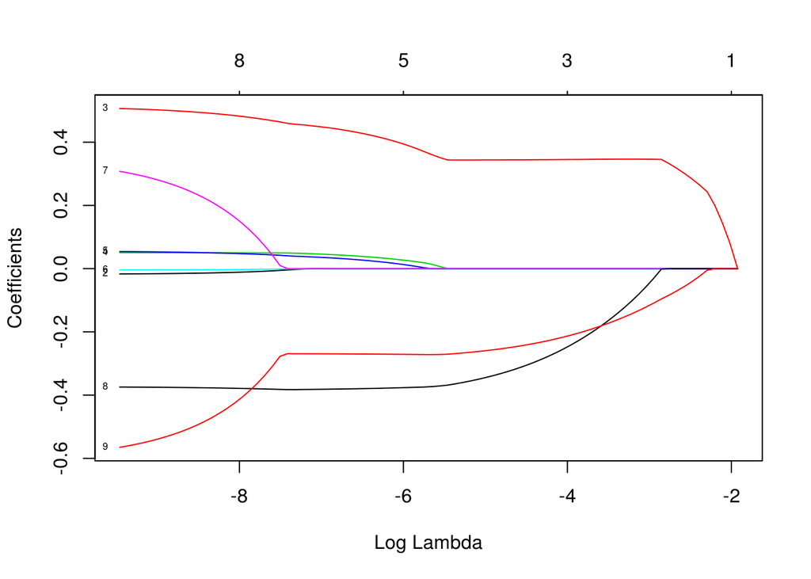

```r
set.seed(123)

model.lasso = glmnet(x = model.matrix( ~ . -matricula -evadiu, train.data),
                y = train.data$evadiu,
                alpha = 1,
                family = 'binomial')

plot(model.lasso, xvar = "lambda", label = T)
```

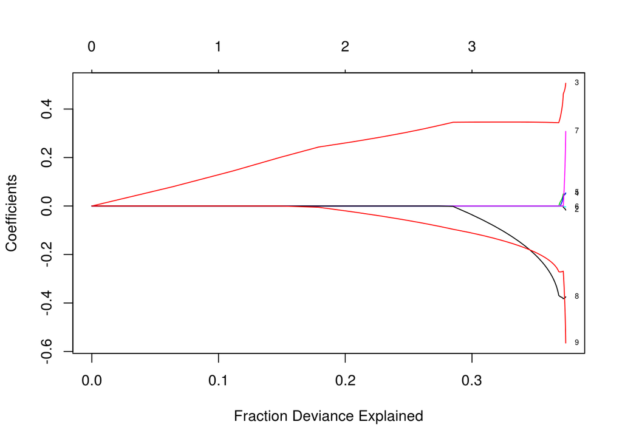

```r
plot(model.lasso,xvar="dev",label=TRUE)
```

```r
coef(model.lasso)[,10]
```

```
##     (Intercept)     (Intercept)             ano num_reprovacoes
##     -2.44348581      0.00000000      0.00000000      0.33234484
##        Vetorial              C1              IC             LP1
##      0.00000000      0.00000000      0.00000000      0.00000000
##             LPT              P1
##      0.00000000     -0.08380514
```

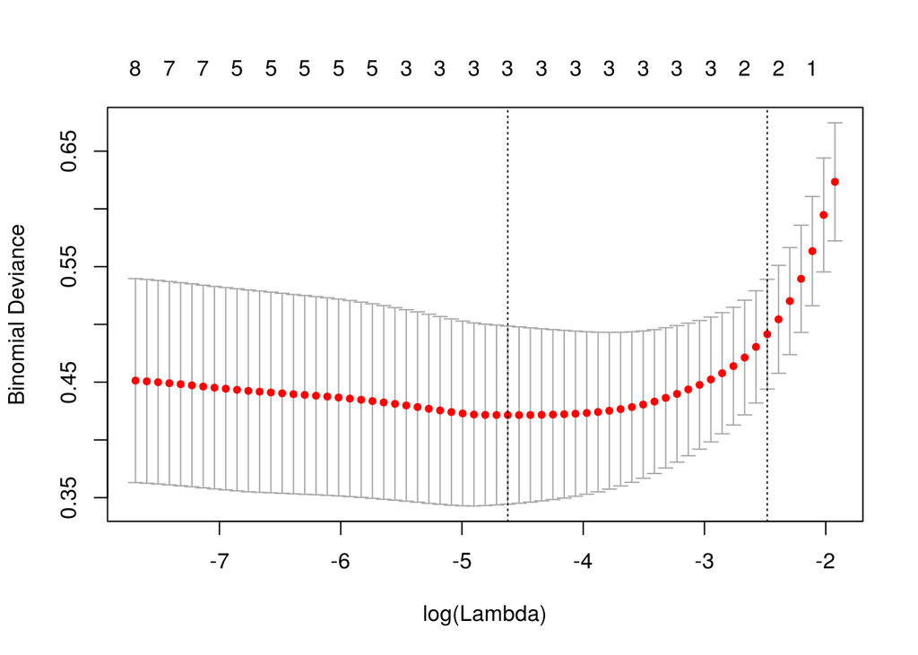

```r
cv.lasso = cv.glmnet(model.matrix( ~ . -matricula -evadiu, train.data),
                     y=train.data$evadiu,
                     alpha=1,
                     family="binomial")
plot(cv.lasso)
```

Assim como em ridge, realizamos o processo para visualização da validação cruzada.

**Árvore de decisão**

Para a árvore de decisões irei utilizar o valor máximo de altura 30. Este é o valor máximo recomendado pela documentação do pacote que utilizarei (rpart).

```r
#Valor máximo da altura da árvore 30
dt.control=rpart.control(maxdepth=30)

decision.tree.fit <- rpart(evadiu ~ . -matricula,
                           data=train.data,
                           method="class",
                           control=dt.control)

printcp(decision.tree.fit)
```

```
##
## Classification tree:
## rpart(formula = evadiu ~ . - matricula, data = train.data, method = "class",
##     control = dt.control)
##
## Variables actually used in tree construction:
## [1] LPT             num_reprovacoes
##
## Root node error: 45/479 = 0.093946
##
## n= 479
##
##        CP nsplit rel error  xerror    xstd
## 1 0.35556      0   1.00000 1.00000 0.14190
## 2 0.13333      1   0.64444 0.64444 0.11599
## 3 0.01000      2   0.51111 0.60000 0.11217
```

```r
#Árvore com menor erro
best.tree<- prune(decision.tree.fit,
 + decision.tree.fit$cptable[which.min(decision.tree.fit$cptable[,"xerror"]),"CP"])
```

**Melhor modelo de regressão logística**

```r
set.seed(123)

fitControl = trainControl(method = "cv", number = 10)
best.glm.model = model.lasso = train(evadiu ~  P1,
                   data=train.data,
                   method="glm",
                   family="binomial",
                   preProcess = c('scale', 'center'),
                   trControl = fitControl,
                   na.action = na.omit)
```

### 7.Acurácia, precision e recall da validação-cruzada e teste

**Regressão Logística**

```r
test.data$best.glm.prediction = predict(best.glm.model, test.data)
temp = test.data %>% select(evadiu, best.glm.prediction)

TP = subset(temp, evadiu == TRUE & best.glm.prediction == TRUE) %>% nrow()
TN = subset(temp, evadiu == FALSE & best.glm.prediction == FALSE) %>% nrow()
FP = subset(temp, evadiu == FALSE & best.glm.prediction == TRUE) %>% nrow()
FN = subset(temp, evadiu == TRUE & best.glm.prediction == FALSE) %>% nrow()

print(paste('Acurácia:', (TP + TN)/(TP+TN+FP+FN)))
```

```
## [1] "Acurácia: 0.947089947089947"
```

```r
print(paste('Precisão:', TP / (TP + FP)))
```

```
## [1] "Precisão: 0.769230769230769"
```

```r
print(paste('Recall:', TP / (TP + FN)))
```

```
## [1] "Recall: 0.588235294117647"
```

**Árvore de Decisão**

```r
best.dt.prediction <- as.data.frame(predict(best.tree, test.data))
temp <- apply(best.dt.prediction['TRUE'], 2, FUN = function(x){return(x > 0.5)})
test.data$best.dt.prediction <- as.factor(temp)

temp <- test.data %>% select(evadiu, best.dt.prediction)

TP <- temp %>% filter(evadiu == TRUE, best.dt.prediction == TRUE) %>% nrow()
TN <- temp %>% filter(evadiu == FALSE, best.dt.prediction == FALSE) %>% nrow()
FP <- temp %>% filter(evadiu == FALSE, best.dt.prediction == TRUE) %>% nrow()
FN <- temp %>% filter(evadiu == TRUE, best.dt.prediction == FALSE) %>% nrow()

print(paste('Accuracy', (TP + TN)/(TP+TN+FP+FN)))
```

```
## [1] "Accuracy 0.952380952380952"
```

```r
print(paste('Precision', TP / (TP + FP)))
```

```
## [1] "Precision 0.7"
```

```r
print(paste('Recall', TP / (TP + FN)))
```

```
## [1] "Recall 0.823529411764706"
```

### 8.Aplicação do melhor modelo

```r
me.data <- data.frame(P1 = 9.8)

me.prediction <- predict(best.glm.model, me.data)
me.prediction
```

```
## [1] FALSE
## Levels: FALSE TRUE
```

Utilizei minha nota na disciplina de P1 e o resultado da predição foi correto, ele mostrou que eu não evadiria após o primeiro período. É importante deixar claro que esse modelo não é tão robusto, visto que ele foi baseado em um conjundo de dados desbalanceados, e nesse caso ele está se baseando apenas em uma única variável para realizar a previsão.

### 9.Conclusões

Para obtermos melhores modelos seria necessário que os dados estivessem balanceados e melhorar a forma de inputação, visto que estamos realizando essa inserção dos dados de uma forma arbitrária. Para balancear os dados isso poderíamos utilizar as técnicas disponíveis, como por exemplo Undersampling, Oversampling, Synthetic Data Generation, Cost Sensitive Learning e utliziar uma inputação mais precisa.